# Funções para gerar exemplos

Autor

Fernando Náufel

Data de Publicação

08/02/2024 17:35

# Problema

Condições:

- A *expert list* (lista) tem $k$ elementos, $k > 0$, não necessariamente ordenados.
- O *ranking* tem $p$ elementos, $p \geq k$, ordenados, sem empates.
- Todos os elementos da lista estão no *ranking*.
- O último elemento do *ranking* é elemento da lista.

Dadas estas condições, desenvolver funções para

- Criar exemplos com pares de listas e *rankings*, cada par em uma *tibble*.
- Construir tabelas coloridas mostrando as posições dos elementos da lista no *ranking*.
- Calcular diferentes medidas de correlação entre lista e *ranking*.
- Construir gráficos.

# Criando exemplos

## Quantidade de exemplos

Dados $k > 0$ e $p \geq k$ fixos, quantos exemplos existem?

A lista é $L = \{ a_1, \ldots, a_k \}$.

Para montar um *ranking*:

1. Escolher um elemento da lista para ser o último do *ranking*:

   $k$ escolhas.
2. Escolher a ordenação dos $k - 1$ elementos restantes da lista:

   $(k - 1)!$ escolhas.
3. Escolher as posições dos $k - 1$ elementos restantes da lista dentre as $p - 1$ posições restantes no *ranking*:

   $\binom{p - 1}{k - 1}$ escolhas.

Quantidade total de *rankings*:

$$k \cdot (k - 1)! \cdot \binom{p - 1}{k - 1}
\quad=\quad
k! \cdot \binom{p - 1}{k - 1}$$

**Atenção**

Os cálculos consideram os $p - k$ elementos do *ranking* que não estão na lista como indistinguíveis.

Só a presença deles importa, a identidade não.

Veja o exemplo a seguir, onde estes elementos são escritos como “?”.

- A lista tem $k = 2$ elementos, chamados de $a$ e $b$.
- O *ranking* tem $p = 4$ elementos.
- Os $6$ *rankings* possíveis são
  - $?\;?\;a\;b$
  - $?\;a\;?\;b$
  - $a\;?\;?\;b$
  - $?\;?\;b\;a$
  - $?\;b\;?\;a$
  - $b\;?\;?\;a$

Quantidades de *rankings*:

| \(p\) | \(k\) 1 | \(k\) 2 | \(k\) 3 | \(k\) 4 | \(k\) 5 | \(k\) 6 | \(k\) 7 | \(k\) 8 | \(k\) 9 | \(k\) 10 |
| --- | --- | --- | --- | --- | --- | --- | --- | --- | --- | --- |
| 1 | 1 |  |  |  |  |  |  |  |  |  |
| 2 | 1 | 2 |  |  |  |  |  |  |  |  |
| 3 | 1 | 4 | 6 |  |  |  |  |  |  |  |
| 4 | 1 | 6 | 18 | 24 |  |  |  |  |  |  |
| 5 | 1 | 8 | 36 | 96 | 120 |  |  |  |  |  |
| 6 | 1 | 10 | 60 | 240 | 600 | 720 |  |  |  |  |
| 7 | 1 | 12 | 90 | 480 | 1.800 | 4.320 | 5.040 |  |  |  |
| 8 | 1 | 14 | 126 | 840 | 4.200 | 15.120 | 35.280 | 40.320 |  |  |
| 9 | 1 | 16 | 168 | 1.344 | 8.400 | 40.320 | 141.120 | 322.560 | 362.880 |  |
| 10 | 1 | 18 | 216 | 2.016 | 15.120 | 90.720 | 423.360 | 1.451.520 | 3.265.920 | 3.628.800 |
| 11 | 1 | 20 | 270 | 2.880 | 25.200 | 181.440 | 1.058.400 | 4.838.400 | 16.329.600 | 36.288.000 |
| 12 | 1 | 22 | 330 | 3.960 | 39.600 | 332.640 | 2.328.480 | 13.305.600 | 59.875.200 | 199.584.000 |
| 13 | 1 | 24 | 396 | 5.280 | 59.400 | 570.240 | 4.656.960 | 31.933.440 | 179.625.600 | 798.336.000 |
| 14 | 1 | 26 | 468 | 6.864 | 85.800 | 926.640 | 8.648.640 | 69.189.120 | 467.026.560 | 2.594.592.000 |
| 15 | 1 | 28 | 546 | 8.736 | 120.120 | 1.441.440 | 15.135.120 | 138.378.240 | 1.089.728.640 | 7.264.857.600 |
| 16 | 1 | 30 | 630 | 10.920 | 163.800 | 2.162.160 | 25.225.200 | 259.459.200 | 2.335.132.800 | 18.162.144.000 |
| 17 | 1 | 32 | 720 | 13.440 | 218.400 | 3.144.960 | 40.360.320 | 461.260.800 | 4.670.265.600 | 41.513.472.000 |
| 18 | 1 | 34 | 816 | 16.320 | 285.600 | 4.455.360 | 62.375.040 | 784.143.360 | 8.821.612.800 | 88.216.128.000 |
| 19 | 1 | 36 | 918 | 19.584 | 367.200 | 6.168.960 | 93.562.560 | 1.283.143.680 | 15.878.903.040 | 176.432.256.000 |
| 20 | 1 | 38 | 1.026 | 23.256 | 465.120 | 8.372.160 | 136.745.280 | 2.031.644.160 | 27.427.196.160 | 335.221.286.400 |

## Criar uma lista com letras maiúsculas

```r
criar_lista <- function(k) {

  stopifnot('Argumento deve ser > 0.' = k > 0)
  sample(LETTERS, k)

}
```

```r
criar_lista(10)
```

```
 [1] "X" "S" "U" "C" "J" "Q" "N" "Y" "V" "B"
```

## Criar um *ranking* a partir de uma lista

A função vai receber a lista, um vetor com as posições dos elementos da lista no *ranking*, e o tamanho $p$ do ranking.

A função retorna um vetor com o *ranking*, onde os elementos que não estavam na lista são escritos como “?”.

```r
criar_ranking <- function(lista, posicoes, p) {

  # Verificar se posicoes contêm só números entre 1 e p, sem repetições
  stopifnot(
    'Posições precisam estar entre 1 e p, sem repetições.' =
    all(between(posicoes, 1, p)) & identical(posicoes, unique(posicoes))
  )

  # Verificar se posicoes contém p (o último do ranking tem q ser da lista)
  stopifnot(
    'O último do ranking precisa ser da lista' = p %in% posicoes
  )

  ranking <- rep('?', p)
  ranking[posicoes] <- lista
  ranking

}
```

[output not shown]

# Representando um exemplo

## Como *tibble*

Para calcular a correlação entre a lista e o *ranking*, vamos precisar ordenar a lista de alguma forma, pois, se todos os elementos da lista estiverem empatados (i.e., se todos tiverem o mesmo valor de posição), podemos cair em um caso em que o desvio-padrão seja $0$.

Dado um *ranking*, a maneira mais conveniente de ordenar a lista afetando a correlação de forma previsível é concordando com o *ranking*!

É isto que esta função faz.

Além disso, os elementos que não estavam na lista mas estão no *ranking*, se existirem, precisam entrar na *tibble*.

Eles vão entrar como estando todos empatados no fim da lista, como no exemplo mais abaixo.

A função retorna uma *tibble* com as colunas `nome`, `pos_lista` e `pos_ranking`.

```r
criar_df <- function(ranking) {

  p <- length(ranking)
  lista <- ranking[ranking != '?']
  k <- length(lista)
  pos_lista <- 1:k
  pos_ranking <- which(ranking %in% lista)

  # Linhas com elementos da lista
  df <- tibble(
    nome = lista,
    pos_lista = pos_lista,
    pos_ranking = pos_ranking
  )

  if (p > k) {

    # Linhas com outros elementos
    nomes <- rep('?', p - k)
    pos_lista <- rep((sum((k+1):p) / (p - k)) , p - k)
    pos_ranking <- which(!(ranking %in% lista))

    df <- df %>%
      bind_rows(
        tibble(
          nome = nomes,
          pos_lista = pos_lista,
          pos_ranking = pos_ranking
        )
      )

  }

  df

}
```

```r
r <- criar_ranking(LETTERS[1:4], c(2, 6, 1, 3), 6)
criar_df(r)
```

| nome | pos_lista | pos_ranking |
| --- | --- | --- |
| C | 1,0 | 1 |
| A | 2,0 | 2 |
| D | 3,0 | 3 |
| B | 4,0 | 6 |
| ? | 5,5 | 4 |
| ? | 5,5 | 5 |

## Como tabela

Uma maneira mais compacta ainda de representar um exemplo de *ranking*.

```r
criar_tabela <- function(ranking) {

  df <- criar_df(ranking) %>%
    select(-pos_lista) %>%
    arrange(pos_ranking) %>%
    pivot_wider(
      names_from = pos_ranking,
      values_from = nome
    )

  df %>%
    gt() %>%
      tab_style(
        cell_fill('red'),
        cells_body(
          columns = where(~ .x == '?')
        )
      )

}
```

```r
r <- criar_ranking(LETTERS[1:4], c(2, 6, 1, 3), 6)
criar_tabela(r)
```

| 1 | 2 | 3 | 4 | 5 | 6 |
| --- | --- | --- | --- | --- | --- |
| C | A | D | ? | ? | B |

Aqui, fica claro quais são e em que posições estão os elementos da lista.

## Como gráfico

A função recebe um *ranking*, na forma de vetor ou de *tibble*.

A função gera um gráfico de pontos, com um ponto para cada elemento.

No eixo $x$, a posição do elemento na lista.

No eixo $y$, a posição do elemento no *ranking*.

A função pode receber, além do *ranking*, uma função para calcular o *score* deste *ranking* (i.e., alguma forma de correlação entre o *ranking* e a lista). O *score* vai ser mostrado no título do gráfico.

Opcionalmente, é incluída uma reta de regressão linear via mínimos quadrados.

```r
criar_plot <- function(ranking, fun = NULL, reta = TRUE) {

  if (!is_tibble(ranking)) {
    ranking <- criar_df(ranking)
  }

  df <- ranking
  p <- nrow(df)

  grafico <- df %>%
    ggplot(aes(pos_lista, pos_ranking)) +
      geom_point() +
      scale_x_continuous(breaks = 1:p, labels = 1:p, limits = c(1, p)) +
      scale_y_continuous(breaks = 1:p, labels = 1:p, limits = c(1, p)) +
      labs(
        x = 'lista',
        y = 'ranking'
      )

  if (!is.null(fun)) {
    score <- do.call(fun, list(df))
    grafico <- grafico + labs(title = paste0('Score = ', score))
  }

  if (reta) {
    grafico <- grafico +
      geom_smooth(
        formula = y ~ x,
        method = 'lm',
        se = FALSE
      )
  }

  grafico

}
```

```r
r <- criar_ranking(LETTERS[1:4], c(2, 6, 1, 3), 6)
```

```r
criar_tabela(r)
```

| 1 | 2 | 3 | 4 | 5 | 6 |
| --- | --- | --- | --- | --- | --- |
| C | A | D | ? | ? | B |

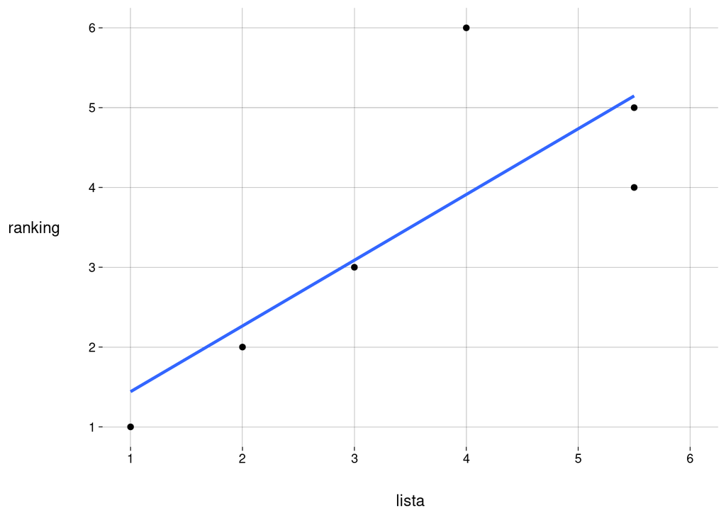

```r
criar_plot(r)
```

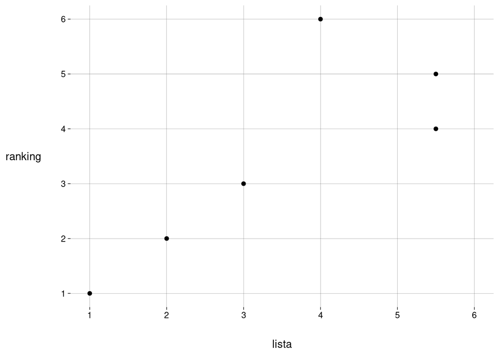

```r
criar_plot(r, reta = FALSE)
```

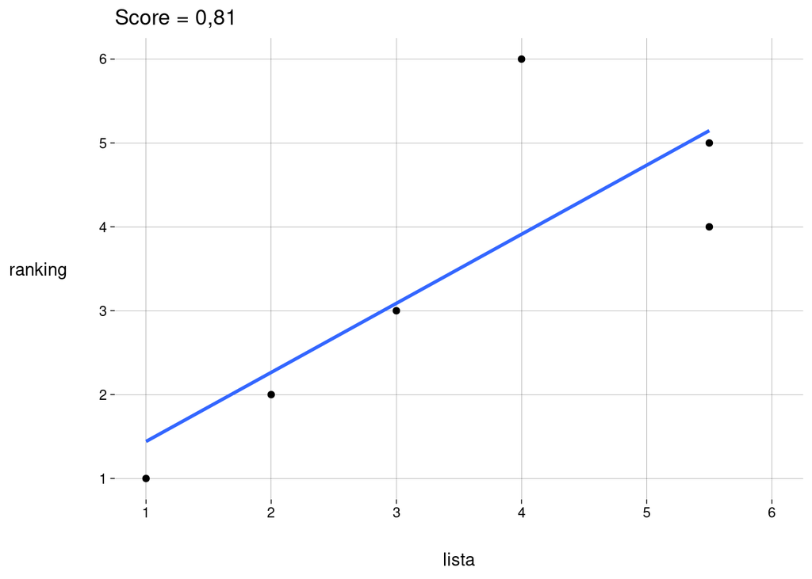

```r
criar_plot(r, \(df) { cor(df$pos_lista, df$pos_ranking) %>% round(2) })
```